# Protección social y capital social relacional en Chile

Protección social y capital social relacional en Chile

Diseño de política y desigualdad relacional

**Alejandro Plaza Reveco** Instituto MIDE UC, Pontificia Universidad Católica de Chile  
Humboldt-Universität zu Berlin

II Mini conferencia sobre desigualdades · Observatorio de Desigualdades UDP  
Mesa 5: Estratificación y movilidad social · Jueves 15 de octubre de 2026

## La cohesión social ya es un objetivo de política pública

OCDE (2012)

pertenencia  
y movilidad ascendente

Definición de sociedad cohesionada

CEPAL (2007)

los mecanismos instituidos de inclusión y exclusión

Sistema de indicadores de cohesión social, p. 21

Chile

Redes y Cohesión Social es una dimensión de la pobreza

El indicador de Apoyo usa el mismo generador de recursos que este estudio (MDS 2024)

Si la cohesión es un objetivo, hay que preguntar qué hacen las políticas sociales con las redes de los hogares.

## Las redes sostienen hacia los lados y conectan hacia arriba

[figure not shown]

**La CASEN observa las tres direcciones**, una por dimensión del generador de recursos. No observa pertenencia ni confianza.

## ¿El Estado desplaza a las redes?

*Crowding-in*

Estados más generosos tienen más confianza y participación.

Rothstein 2001 · van Oorschot y Arts 2005 · nivel macro, países OCDE

*Crowding-out*

La provisión formal desplaza la ayuda informal entre hogares.

Cox et al. 1998 · Kinnan y Townsend 2012 · Dupas et al. 2019 · nivel micro

Una lectura paralela: si el Estado libera a las personas de depender de la familia, la autonomía puede ser el objetivo y no un costo. Es la idea de un individualismo estatal.

**Ferragina (2017):** la *generosidad* del Estado de bienestar se asocia a más capital social; su *tamaño*, a menos. El signo depende de cómo interviene el Estado. Falta especificar el mecanismo.

## Cada vía de intervención busca algo y puede costar algo

| Vía | Lo que busca | Lo que evita | Lo que puede costar |
| --- | --- | --- | --- |
| Sustituir transferencias | Aliviar la carencia material | Depender de préstamos y obligaciones de reciprocidadKinnan y Townsend 2012 | Desplazar la ayuda privadaCox et al. 1998; Dupas et al. 2019 |
| **Liberar** cuidado | Autonomía frente a obligaciones familiaresEsping-Andersen 1999 | El lado oscuro del capital socialPortes 1998 | Sobreautonomización: menos apoyo y pertenenciaBerggren y Trägårdh 2006, y sus críticos |
| **Intermediar** acompañamiento | Conectar a la familia con la oferta públicaLipsky 1980 | Que el acceso dependa de intermediarios políticosAuyero 2000; Handlin 2013 | Una relación individual con el Estado, sin articulación colectivaLuna 2014 |
| **Reunir** espacios grupales | Copresencia repetida que crea vínculosFeld 1981; Small 2009; Feigenberg et al. 2013 | El aislamiento | Cierre entre iguales: más apoyo, poco alcance hacia arribaMcPherson et al. 2001 |

■ Este estudio compara dos entregas del mismo monto (SUF y Asignación Familiar) y contrasta el acompañamiento (intermediar), sin poder estadístico suficiente.

## Si el Estado sustituye, la pérdida estaría en el apoyo; si no, arriba

[figure not shown]

Lo que discrimina entre mecanismos es dónde aparece la diferencia, no cuánto mide.

Prueba adicional: si fuera un repliegue hacia el hogar, lo que se pierde afuera debería compensarse adentro.

## Tres instrumentos: dos pagan lo mismo y solo cambia la vía de entrega

|  | SUF | Asignación Familiar tramo 1 | Seguridades y Oportunidades |
| --- | --- | --- | --- |
| Quién | 60% más vulnerable del RSH, sin derecho a Asignación Familiar | Trabajadores formales y pensionados de ingreso bajo, por sus cargas | Familias en pobreza extrema, invitadas |
| Cómo se obtiene | Se postula en el municipio | Automática, por el empleador o la entidad que paga la pensión | Invitación y acompañamiento hasta 24 meses |
| Monto | $11.091 (2017) · $16.418 (2022) por causante | **El mismo, por ley** | Bonos del subsistema |
| Contacto con el Estado | Trámite y depósito; marca de beneficiario | Ninguno: es un derecho laboral | Un profesional en el hogar |
| CASEN | y20a–d · 2017 y 2022 | y19t = 1 · 2017 y 2022 | y21a–b · solo 2017 |

SUF y Asignación Familiar son excluyentes por ley y pagan lo mismo por hijo: lo más cercano a un experimento de mismo dinero, distinta arquitectura.

## A quién puede recurrir el hogar, y si esa persona está dentro o fuera

*“¿Alguien en su hogar conoce a una persona que…?”*

Instrumental y cuidado (4)  
cuide a un enfermo · cuide niños · facilite un vehículo · preste dinero

Práctico e institucional (5)  
trámites · tecnologías · reparaciones · conseguir trabajo · consejo

Alto estatus (2)  
hable otro idioma · tenga título universitario

Codificación de cada ítem

**1** = alguien de fuera del hogar (incluye “ambas”)  
**0** = solo dentro, o no conoce

Resultado

Proporción de ítems de cada dimensión con fuente externa: se lee en puntos porcentuales

CASEN 2017 (70.948 hogares) y 2022 (72.056)

## Los once ítems forman tres dimensiones, estables entre olas y grupos

[figure not shown]

|  | CFI | TLI | RMSEA | SRMR | ω (IC / PI / AE) | Invarianza escalar |
| --- | --- | --- | --- | --- | --- | --- |
| 2017 | 0,982 | 0,976 | 0,078 | 0,052 | 0,95 / 0,91 / 0,84 | entre olas: ΔCFI +0,004 |
| 2022 | 0,977 | 0,969 | 0,083 | 0,060 | 0,94 / 0,90 / 0,81 | SUF vs. no SUF: ΔCFI ≤ 0,004 |

AFC para indicadores binarios (WLSMV). Cargas estandarizadas de 2017; en 2022 varían entre −0,05 y +0,01.

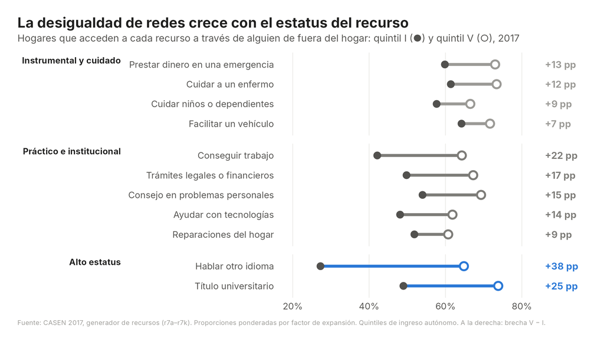

## Comparar hogares parecidos y acotar lo que no se observa

[figure not shown]

**1. Estimación principal** *Entropy balancing* + regresión (doblemente robusto); bootstrap de conglomerados; corrección de Holm

**2. Robustez** solo hogares elegibles · bosques causales · estratos de propensión

**3. Sensibilidad a U** Rosenbaum · Cinelli y Hazlett

**4. Arquitecturas** SUF vs. Asignación Familiar (mismo monto), registrado antes de estimar

Asociación ajustada, no efecto causal. Detalle de cada método en el respaldo y en alejandroplazareveco.github.io.

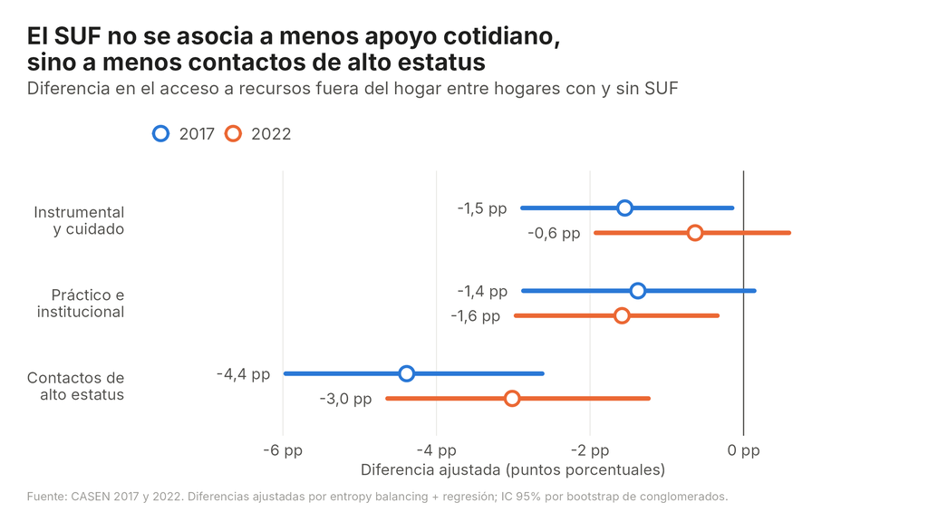

apoyo e  
instituciones

estatus

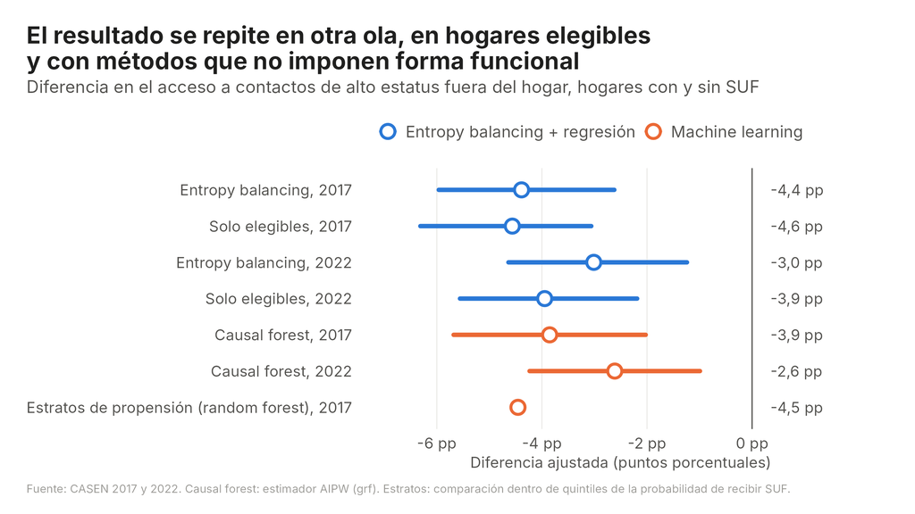

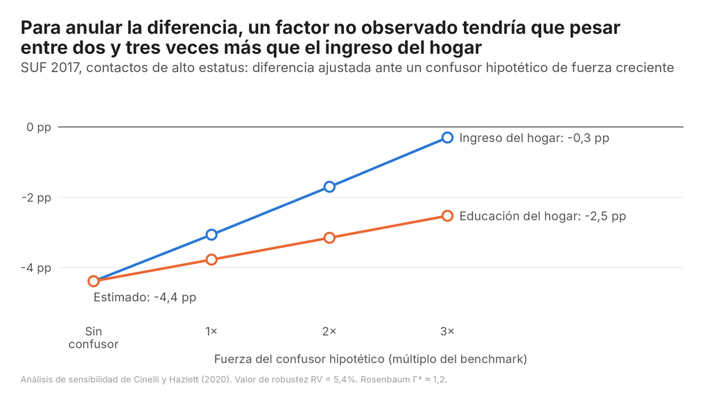

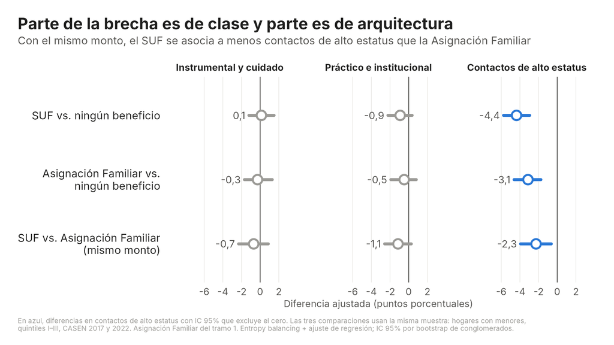

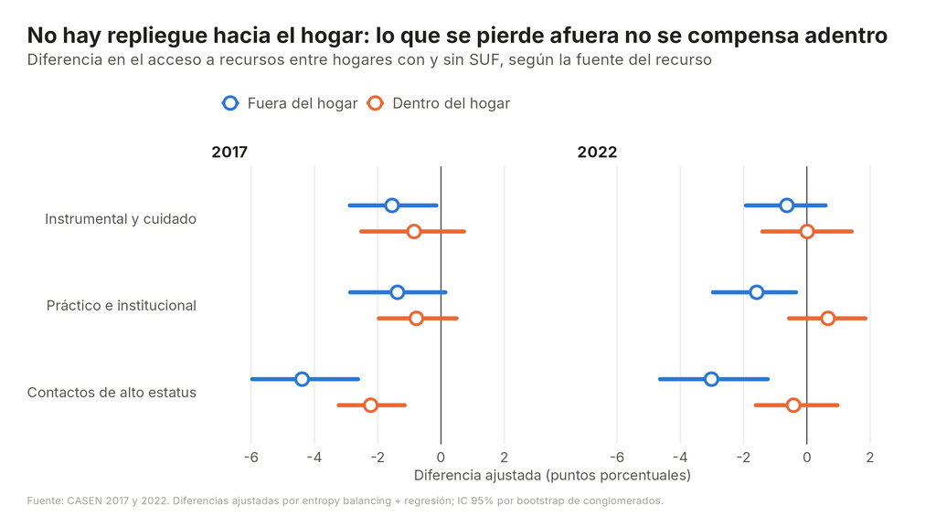

## El apoyo se mantiene; el alcance de estatus se estrecha, por clase y por arquitectura

Hallazgo

Con ninguna política cambian el apoyo cotidiano ni el acceso a instituciones.

El acceso a contactos de alto estatus es 7–10% menor: una parte acompaña a la clase; otra, menor, es propia de la entrega focalizada (−2,3 frente a la Asignación Familiar).

Implicancias

La focalización no crea la desigualdad relacional, pero la profundiza en el margen.

Las transferencias no erosionan la solidaridad cotidiana.

Desagregar el indicador de Apoyo por tipo de recurso.

Límites y agenda

Selección en observables. La CASEN 2024 eliminó los dos ítems: 2017 y 2022 son las únicas olas.

Siguientes pasos: discontinuidad en el umbral del RSH, que separa elegibilidad de clase; proyecto EPS–IPS sobre pensiones y redes en la vejez.

Muchas gracias

**Alejandro Plaza Reveco** Instituto MIDE UC, Pontificia Universidad Católica de Chile  
Humboldt-Universität zu Berlin

Dudas o consultas: aplazareveco@gmail.com

La presentación y los materiales suplementarios estarán disponibles en  
[alejandroplazareveco.github.io](https://alejandroplazareveco.github.io/)

# Respaldo

Preguntas probables, figuras y tablas

## Índice de respaldo

Preguntas

¿No reciben SUF justamente los más aislados?  
¿Es un efecto causal?  
¿“Otro idioma” no mide lenguas originarias?  
¿Por qué es menor en 2022?  
¿Por qué no un RDD?  
¿Cómo $11 mil pesos reducen contactos?  
El programa institucional da −5,2  
Rosenbaum Γ* = 1,2 es bajo  
¿Hay que recortar el SUF?  
¿Interno/externo es bonding/bridging?  
¿La Asignación Familiar no es empleo formal?  
¿Por qué el RV del contraste es más bajo?  
¿Seguridades y Oportunidades en 2022?  
¿Y los jardines infantiles?  
¿Y la CASEN 2024?

Figuras y tablas

Desigualdad por ítem, 2022  
Desigualdad por dimensión y quintil  
Efecto por especificación  
Ítems de alto estatus por separado  
Ítems por pertenencia indígena  
Todas las arquitecturas ampliadas  
Tabla: mismo monto, distinta arquitectura  
Acompañamiento vs. SUF (2017)  
Esquema de un árbol causal  
Tabla: efectos principales  
Tabla: sensibilidad  
Tabla: contrastes de arquitectura

## ¿No reciben SUF justamente los hogares más aislados?

- Comparo hogares con igual ingreso autónomo, educación, composición, territorio, etnia y migración. Entre elegibles el resultado se mantiene: −4,6 pp.
- Para anular la diferencia, el capital social previo tendría que pesar entre 2 y 3 veces más que el ingreso (RV = 5,4%).
- Hay dos selecciones de signo opuesto. En el *acceso* (quien tiene más redes postula más) la estimación sería conservadora. En la *elegibilidad* (la focalización elige hacia abajo) estaría inflada.
- La Asignación Familiar muestra que la segunda existe: sin postulación ni marca, también se asocia a −3,1. Por eso separo clase (−3,1) de arquitectura (SUF vs. Asignación Familiar: −2,3).

← índice

## ¿Es un efecto causal?

- No, y no lo presento así: es una diferencia ajustada bajo selección en observables.
- Lo que sostengo es la forma: la diferencia está en alto estatus y no en el apoyo instrumental. Ese patrón resiste confusores del tamaño de los observados; el tamaño exacto, no.
- Que el apoyo instrumental no cambie es lo que permite descartar la sustitución funcional.
- Que la diferencia esté en la dimensión más ligada a la clase es también lo que produciría una selección residual por clase: por eso la sensibilidad es central.

← índice

## ¿“Otro idioma” no registra lenguas originarias?

- Puede hacerlo; por eso reporto cada ítem por separado.
- El ítem menos ambiguo, título universitario, cae −4,4 pp en 2017 (−8% sobre una base de 54%) y −4,7 entre elegibles.
- En 2022 la atenuación está en el título (−2,3); el idioma se mantiene (−3,9).
- Por pertenencia indígena no hay un patrón consistente: en 2017 la brecha menor está en idioma; en 2022, en título. Ninguna diferencia entre grupos es significativa.

← índice · ver figura

## ¿Por qué la diferencia es menor en 2022?

- Son dos cortes transversales, no una tendencia.
- Casi todos los hogares recibieron el Ingreso Familiar de Emergencia en 2021: el grupo de control está parcialmente tratado y el contraste se atenúa.
- Entre elegibles, 2022 da −3,9 pp, cerca de 2017.
- 2022 es más frágil: RV = 3,9% en la dimensión y 2,3% en título universitario, que se anula ante un confusor del doble de fuerza que el ingreso.

← índice

## ¿Por qué no una regresión discontinua?

- Es el siguiente paso: el umbral de elegibilidad del RSH permitiría una identificación causal local.
- La CASEN no contiene el puntaje de calificación socioeconómica ni está vinculada al Registro Social de Hogares.
- Requiere vincular el módulo de redes con registros administrativos que hoy no están disponibles.
- Aun así, identificaría un efecto *local* en el umbral, no el promedio sobre los tratados.

← índice

## ¿Cómo $11 mil pesos reducirían contactos de alto estatus?

- No lo identifico: el mecanismo es interpretación de la forma del efecto, no objeto de estimación.
- Repliegue de frontera: con menos necesidad de sostener una red amplia, se sueltan primero los vínculos distantes. Se debilita porque no hay compensación dentro del hogar.
- Recodificación categorial: la condición de beneficiario marca socialmente al hogar (Soss 1999; Mettler y Soss 2004). Consistente, no identificada.
- El instrumento mide acceso, no vínculos: no distingue perder un lazo de que un lazo deje de cumplir esa función.

← índice

## El programa institucional da −5,2 en alto estatus

- Son 1.189 hogares tratados: estimación imprecisa (EE ≈ 1,9) que el emparejamiento 1:1 no reproduce.
- El contraste directo con el SUF en esa dimensión es 0,0 (EE 2,1).
- No puedo afirmar que las arquitecturas sean iguales ni distintas: el diseño solo detecta diferencias de 5–6 pp.
- La medición mezcla dos generaciones de programa y solo existe en 2017. Reconstruirla en 2022 con las transferencias del subsistema no es confiable (κ = 0,30).

← índice · ver figura

## Las cotas de Rosenbaum (Γ* ≈ 1,2) son bajas

- El test de rangos sobre pares 1:1 pierde poder con un resultado que toma solo tres valores (0, ½, 1).
- Cinelli y Hazlett es más informativo: expresa la fuerza del confusor en R² parciales y la compara con covariables observadas.
- Resiste un confusor tres veces tan fuerte como la educación del hogar (−2,5) y se anula con uno tres veces tan fuerte como el ingreso (−0,3).

← índice · ver tabla

## ¿La implicancia es recortar el SUF?

- No. El apoyo cotidiano no cambia con el SUF: el argumento de la erosión de la solidaridad no se sostiene.
- Medición: el indicador de Apoyo valora más el contacto externo, pero no distingue tipo de recurso. Desagregarlo lo haría sensible justo a la dimensión que varía.
- Diseño (hipótesis): lo que genera vínculos es la copresencia horizontal repetida, no la intensidad de la intervención.

← índice

## ¿Interno/externo es lo mismo que *bonding*/*bridging*?

- No necesariamente: un vínculo externo puede ser fuerte y cerrado, y puede haber lazos puente dentro del hogar.
- Uso interno/externo como propiedad observable y dejo la lectura bonding/bridging como interpretación tentativa.
- El hogar es foco de interacción (Feld 1981) y frontera de clausura (Blau 1977). La medida de pobreza multidimensional adopta la misma jerarquía.

← índice

## ¿La Asignación Familiar no es simplemente empleo formal?

- Es la amenaza principal del contraste, y la registré antes de estimar como hipótesis rival (“foco laboral”).
- Si fuera el lugar de trabajo, la diferencia debería aparecer en lo práctico y en *conseguir trabajo*, y caer al balancear por formalidad.
- No ocurre: con formalidad laboral (cotización de la jefatura y del hogar) la diferencia en alto estatus queda en −2,2 (97% de la original); *conseguir trabajo* no difiere (−1,7; p = 0,14).
- La diferencia es solo externa: dentro del hogar, ambos grupos no difieren (+0,1).

← índice · ver tabla

## ¿Por qué el RV del contraste es más bajo que el del efecto principal?

- Porque el efecto es más chico (−2,3 vs. −4,4): RV = 2,9% vs. 5,4%.
- Pero resiste mejor a confusores del tipo de los observados, porque compara hogares que ya comparten posición social: con un confusor tres veces tan fuerte como el ingreso queda en −0,8 sin cambiar de signo; tres veces la educación del hogar, −1,9.
- El efecto principal, en cambio, se anula con el ingreso ×3 (−0,3).

← índice

## ¿Seguridades y Oportunidades en 2022?

- La pregunta de participación (y21) no existe en 2022.
- Intenté reconstruirla con las transferencias del subsistema: Bono de Protección, Bono Base Familiar y bonos por deberes.
- Validado contra el autorreporte de 2017 no sirve: κ = 0,30, sensibilidad 0,45, VPP 0,27.
- Con ese indicador el acompañamiento no cambia nada (alto estatus −0,1; EE 1,6), pero el error de clasificación impide interpretar ese nulo.

← índice

## ¿Y los jardines infantiles (JUNJI/Integra)?

- Es la arquitectura que sí produce copresencia (Small 2009), así que la exploré.
- Frente a otro proveedor: sin poder suficiente (efecto mínimo detectable ≈ 5,8 pp; en 2022 solo 490 controles).
- Frente a no asistir: el control está sesgado (el cuidado familiar sustituye al jardín) y el empleo materno es mediador.
- Resultado exploratorio: nada distinguible de cero (alto estatus −1,7; EE 1,6). Queda como agenda.

← índice

## ¿Y la CASEN 2024?

- La CASEN 2024 eliminó justamente los dos ítems de alto estatus (idioma y título universitario) del generador de recursos.
- 2017 y 2022 son, por ahora, las únicas olas que permiten esta prueba.
- Una medición más amplia del acceso a personas de mayor posición (generador de posiciones) fortalecería el hallazgo.

← índice

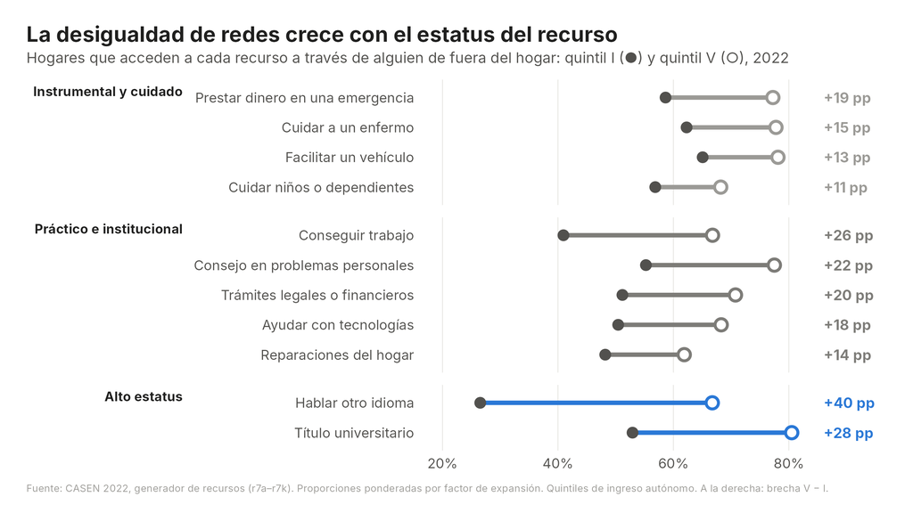

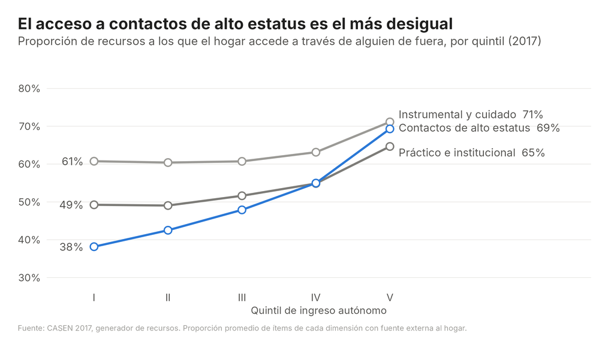

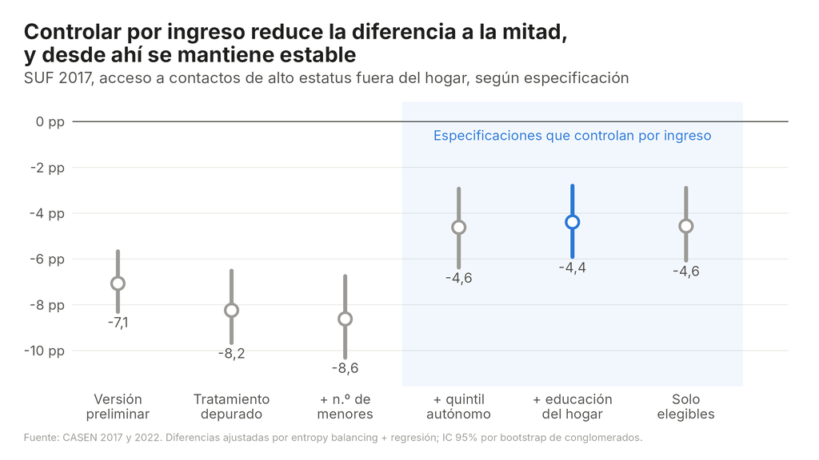

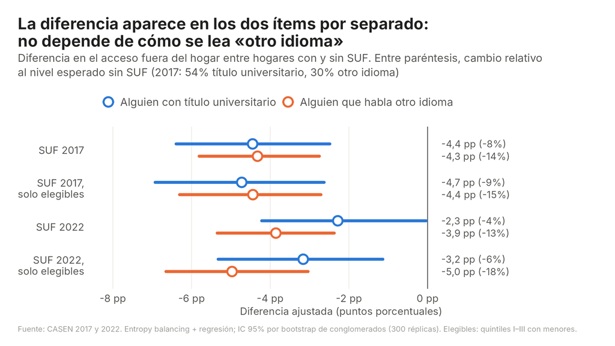

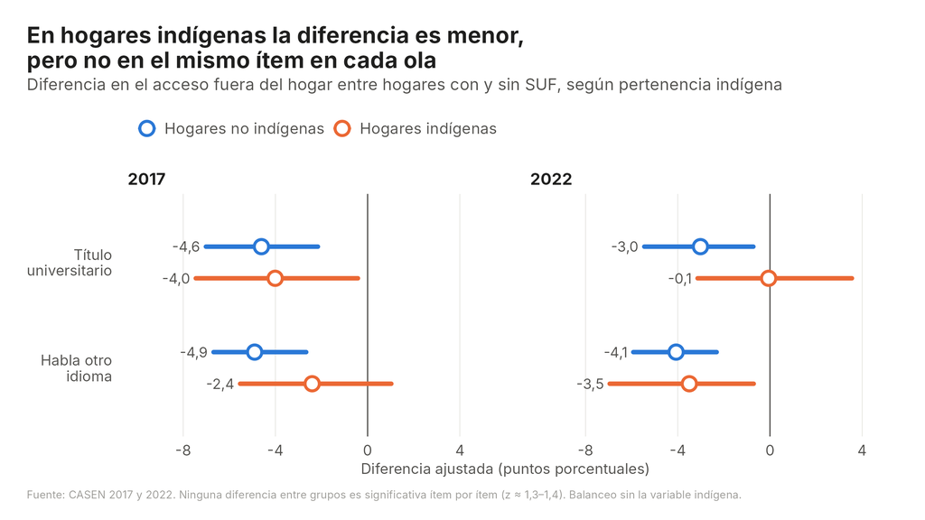

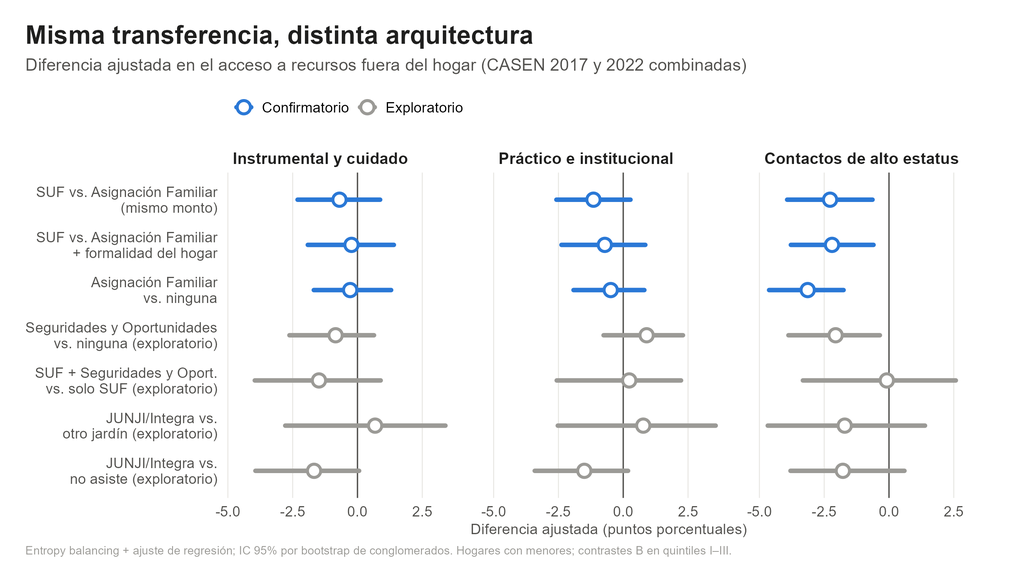

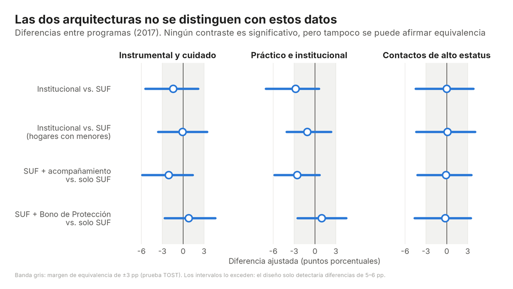

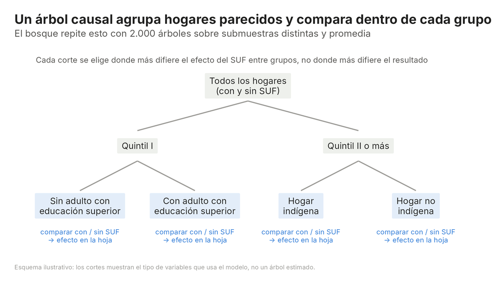

## Efecto sobre el acceso a recursos fuera del hogar

| Comparación | N trat. | Instrumental | Práctico | Alto estatus |
| --- | --- | --- | --- | --- |
| *Entropy balancing + regresión* |  |  |  |  |
| SUF 2017 | 6.060 | −1,5 (0,7) | −1,4 (0,8) | **−4,4** (0,8)*** |
| SUF 2022 | 6.417 | −0,6 (0,7) | −1,6 (0,7) | **−3,0** (0,9)** |
| Programa institucional 2017 | 1.189 | −3,2 (1,9) | −4,5 (1,9) | **−5,2** (1,9)* |
| SUF 2017, elegibles | 5.594 | −0,7 (0,8) | −0,8 (0,8) | **−4,6** (0,9) |
| SUF 2022, elegibles | 5.497 | −0,6 (0,8) | −1,7 (0,8) | **−3,9** (0,9) |
| *Bosques causales (AIPW)* |  |  |  |  |
| SUF 2017 | 6.060 | −0,1 (0,9) | −0,5 (0,9) | **−3,9** (0,9) |
| SUF 2022 | 6.417 | −0,4 (0,7) | −0,8 (0,7) | **−2,6** (0,8) |

ATT en pp; EE entre paréntesis (bootstrap de conglomerados, 500 réplicas). Holm sobre las tres primeras filas: * p < 0,05; ** p < 0,01; *** p < 0,001. Escalón 2017: alto estatus vs. instrumental −2,8 (p = 0,007); vs. práctico −3,0 (p = 0,001); práctico vs. instrumental +0,2 (p = 0,81). ← índice

## Sensibilidad del efecto en contactos de alto estatus

|  | SUF 2017 | SUF 2017 eleg. | SUF 2022 | SUF 2022 eleg. |
| --- | --- | --- | --- | --- |
| ATT estimado | −4,4 | −4,6 | −3,0 | −3,9 |
| Rosenbaum Γ* | 1,20 | — | 1,15 | — |
| Valor de robustez RV | 5,4% | 5,7% | 3,9% | 5,1% |
| *Confusor k veces tan fuerte como…* |  |  |  |  |
| ingreso autónomo, k = 1 | −3,1 | −3,4 | −1,9 | −3,0 |
| ingreso autónomo, k = 2 | −1,7 | −2,2 | −0,8 | −2,1 |
| ingreso autónomo, k = 3 | −0,3 | −1,0 | +0,4 | −1,1 |
| capital educativo del hogar, k = 3 | −2,5 | −3,0 | −1,8 | −2,9 |
| escolaridad de la jefatura, k = 3 | −2,9 | −2,3 | −1,8 | −2,2 |

pp. RV: fuerza mínima (R² parcial con tratamiento y resultado) que llevaría el efecto a cero (Cinelli y Hazlett 2020). Leer las magnitudes ajustadas, no su significancia. ← índice

## Mismo monto, distinta arquitectura: SUF y Asignación Familiar

| Contraste | N trat. / ctrl. | Instrumental | Práctico | Alto estatus | Conseguir trabajo |
| --- | --- | --- | --- | --- | --- |
| *2017 y 2022 combinadas* |  |  |  |  |  |
| SUF vs. ningún beneficio (descriptivo) | 9.052 / 20.245 | +0,1 (0,7) | −0,9 (0,7) | **−4,4** (0,8) | −0,3 (1,0) |
| Asignación Familiar vs. ningún beneficio | 5.601 / 20.245 | −0,3 (0,8) | −0,5 (0,7) | **−3,1** (0,7)*** | +1,4 (0,9) |
| SUF vs. Asignación Familiar | 9.052 / 5.548 | −0,7 (0,8) | −1,1 (0,7) | **−2,3** (0,8)* | −1,7 (1,1) |
| … + formalidad laboral | 9.052 / 5.548 | −0,2 (0,9) | −0,7 (0,8) | **−2,2** (0,8) | −0,9 (1,2) |
| *Por ola: SUF vs. Asignación Familiar* |  |  |  |  |  |
| 2017 | 4.756 / 2.708 | −1,6 (1,0) | −1,6 (1,1) | −2,5 (1,2) | −2,6 (1,5) |
| 2022 | 4.296 / 2.840 | +0,3 (1,1) | −1,0 (1,1) | −2,1 (1,2) | −1,3 (1,4) |

pp; EE por bootstrap de conglomerados (300 réplicas). Hogares con menores, quintiles I–III. Asignación Familiar del tramo 1. Holm sobre la familia confirmatoria registrada antes de estimar (dos contrastes × tres dimensiones): * p < 0,05; *** p < 0,001. La fila “SUF vs. ningún beneficio” es descriptiva (estimada después). ← índice

## Contrastes directos de arquitectura (2017)

| Contraste | N trat. | Instrumental | Práctico | Alto estatus |
| --- | --- | --- | --- | --- |
| Institucional vs. SUF | 1.189 | −1,4 (2,0) | −2,8 (2,1) | 0,0 (2,1) |
| Institucional vs. SUF, hogares con menores | 677 | −0,1 (1,7) | −1,1 (1,7) | +0,1 (2,1) |
| SUF + acompañamiento vs. solo SUF | 600 | −2,1 (1,8) | −2,5 (1,7) | −0,1 (1,9) |
| SUF + Bono de Protección vs. solo SUF | 577 | +0,8 (2,0) | +1,0 (1,9) | −0,2 (2,1) |

pp; EE por bootstrap de conglomerados. Ningún contraste es significativo al 5%. La equivalencia (±3 pp, TOST) no se confirma salvo en la dimensión instrumental en hogares con menores. ← índice